# How do various factors affect and help predict house prices in King County, USA?

## Project 1

### 1. Introduction

The goal of this project is to determine how certain factors such as the area of living space, the quality of construction materials used, quality of view from the house, location and hours of sunlight in a month affect the price of houses sold in King County, USA in 2014 and 2015. This information will be used to derive a method to predict future values of house sales. The data about the house sales in King County was obtained from https://www.kaggle.com/harlfoxem/housesalesprediction. It also includes information about number and types of rooms in the houses, number of floors and when they were built and renovated as shown in the table below.

```python
import pandas as pd
import seaborn as sns
import matplotlib.pyplot as plt
import numpy as np
import geopandas as gpd
from shapely.geometry import Point
%matplotlib inline
import qeds
qeds.themes.mpl_style();
plotly_template = qeds.themes.plotly_template()
colors = qeds.themes.COLOR_CYCLE
import statsmodels.api as sm
from statsmodels.iolib.summary2 import summary_col
from linearmodels.iv import IV2SLS
from sklearn import (
    linear_model, metrics, pipeline, model_selection
)

df_kc = pd.read_csv("kc_house_data.csv")
df_kc.head().style.set_caption('King County House Sales Data for 2014-15')
```

King County House Sales Data for 2014-15

|  | id | date | price | bedrooms | bathrooms | sqft_living | sqft_lot | floors | waterfront | view | condition | grade | sqft_above | sqft_basement | yr_built | yr_renovated | zipcode | lat | long | sqft_living15 | sqft_lot15 |
| --- | --- | --- | --- | --- | --- | --- | --- | --- | --- | --- | --- | --- | --- | --- | --- | --- | --- | --- | --- | --- | --- |
| 0 | 7129300520 | 20141013T000000 | 221900.000000 | 3 | 1.000000 | 1180 | 5650 | 1.000000 | 0 | 0 | 3 | 7 | 1180 | 0 | 1955 | 0 | 98178 | 47.511200 | -122.257000 | 1340 | 5650 |
| 1 | 6414100192 | 20141209T000000 | 538000.000000 | 3 | 2.250000 | 2570 | 7242 | 2.000000 | 0 | 0 | 3 | 7 | 2170 | 400 | 1951 | 1991 | 98125 | 47.721000 | -122.319000 | 1690 | 7639 |
| 2 | 5631500400 | 20150225T000000 | 180000.000000 | 2 | 1.000000 | 770 | 10000 | 1.000000 | 0 | 0 | 3 | 6 | 770 | 0 | 1933 | 0 | 98028 | 47.737900 | -122.233000 | 2720 | 8062 |
| 3 | 2487200875 | 20141209T000000 | 604000.000000 | 4 | 3.000000 | 1960 | 5000 | 1.000000 | 0 | 0 | 5 | 7 | 1050 | 910 | 1965 | 0 | 98136 | 47.520800 | -122.393000 | 1360 | 5000 |
| 4 | 1954400510 | 20150218T000000 | 510000.000000 | 3 | 2.000000 | 1680 | 8080 | 1.000000 | 0 | 0 | 3 | 8 | 1680 | 0 | 1987 | 0 | 98074 | 47.616800 | -122.045000 | 1800 | 7503 |

A quick overview of the correlation between all these factors can be seen from the following heatmap. Price being the output variable, the area of living space (sqft_living) and the quality of construction materials used (grade) have the highest absolute correlation with price followed by number of bathrooms (bathrooms) and quality of view (view).

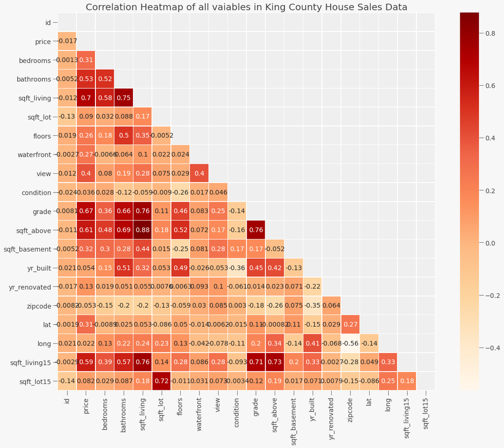

```python
cor = df_kc.corr(method = "pearson")
plt.figure(figsize=(19,15))
ax = plt.axes()
mask = np.triu(np.ones_like(cor, dtype=bool))
sns.heatmap(cor, mask=mask, annot=True, square=True, linewidth=0.5, cmap='OrRd')
ax.set_title('Correlation Heatmap of all vaiables in King County House Sales Data')
plt.show()
```

The heatmap shows that price has the highest correlation with:

```
- Area of living space (sqft_living) of 0.7
- Quality of construction materials used (grade) of 0.67
- Number of bathrooms (bathrooms) of 0.53
- Quality of view (view) of 0.4
```

Thus these will be the primary focus for understanding and predicting price differences. A few variables such as 'sqft_above' and 'sqft_living15' have a high correlation too but they represent information very similar to 'sqft_living'. Including them would be counter-intuitive to building a "simple" model to predict house prices.

Apart from forming a useful formula to predict prices, this project also looks at how factors such as location and climate affect house sale values. For instance, house sales are categorised according to zipcodes in King County to create a heatmap visual of relatively expensive places. Similarly, climate data for Seattle in King County, not available in the house sales data presented above, is web-scraped to create graphical representations showcasing the effects of climate differences every month on house sales. These visualisations indicate that houses are more expensive towards the west and sunnier months see higher values for house sales.

### 2. Summary Statistics

The five variables which are the primary focus in this study, 'price', 'sqft_living', 'grade', 'bathrooms' and 'view', are extracted in to a new table and their statistical information is given below.

```python
df_kc2 = df_kc[["price", "sqft_living", "grade", "bathrooms", "view"]].copy()
df_kc2.dropna()
df_kc2.describe()
```

|  | price | sqft_living | grade | bathrooms | view |
| --- | --- | --- | --- | --- | --- |
| count | 2.161300e+04 | 21613.000000 | 21613.000000 | 21613.000000 | 21613.000000 |
| mean | 5.400881e+05 | 2079.899736 | 7.656873 | 2.114757 | 0.234303 |
| std | 3.671272e+05 | 918.440897 | 1.175459 | 0.770163 | 0.766318 |
| min | 7.500000e+04 | 290.000000 | 1.000000 | 0.000000 | 0.000000 |
| 25% | 3.219500e+05 | 1427.000000 | 7.000000 | 1.750000 | 0.000000 |
| 50% | 4.500000e+05 | 1910.000000 | 7.000000 | 2.250000 | 0.000000 |
| 75% | 6.450000e+05 | 2550.000000 | 8.000000 | 2.500000 | 0.000000 |
| max | 7.700000e+06 | 13540.000000 | 13.000000 | 8.000000 | 4.000000 |

All the values for the three columns are present therefore the count indicates 21,613 for all of them; it is the same as the number of rows in the original dataset. The grade of the houses, or the quality of construction materials used, ranges from 1 to 13. The price has a median of 450,000 but its mean is 540,088 thus its distribution is positively skewed. Price has a huge standard deviation in relation to the magnitude of its mean, compared to the standard deviation and mean of the other variables. To deal with the huge range and variance, subsequent analysis will be based on natural log of price. On a more analytic note, it can be observed that for every quartile of data, sqft_living has a more linear positive relationship with price than grade with price. While sqft_living and price show steady increase in magnitude, grade has the same magnitude over the first and second quartile, 7.0, then increases by a tiny bit over the third quartile, 8.0, and ends at a very high value of 13.0. This suggests a non-linear exponential relationship of grade and price. The bathrooms variable has a mean of 2.11 while it's max stands at 8 eventhough the third quartile ends at 2.5, suggesting that there may be a few outliers affecting range. Lastly, view has a very distorted distribution as more than three quarters of values are 0 while maxing at 4. While this vairable has a high correlation with price as seen in the heatmap, it may not be significant due to lack of data for view values other than 0.

## Project 2

### 3. Graphical Representation

The research question asks for understanding the effects of these variables on house sales. This can be best achieved by visualising how every variable individually affects prices on different graphs. Area of living space presents continuous data that ranges over several square feet which suggests that a scatter plot would best represent its relationship with price. Quality of Construction Materials and number of bathrooms on the other hand has discrete data that ranges from 1 to 13 thus a box plot seems the right fit for it. All the data would be plotted against the natural log of price. Additionally, houses with more than 6000 feet of living space, constructed with materials of quality below 4 and houses with 0 or more than 4.5 bathrooms will be dropped from the dataset as they represent a tiny portion of data but have extreme price values and are outliers.

```python
# Drop unwanted values
m = []
for i in range(len(df_kc2)):
    if df_kc2['sqft_living'][i] > 6000 or df_kc2['bathrooms'][i] > 4.5 or df_kc2['bathrooms'][i] == 0 or df_kc2['grade'][i] < 4:
        m.append(i)
df_kc2 = df_kc2.drop(df_kc2.index[m]).reset_index(drop=True)
```

```
Fit model: log(price) = [12.19908907] + [0.00040881] sqft_living
```

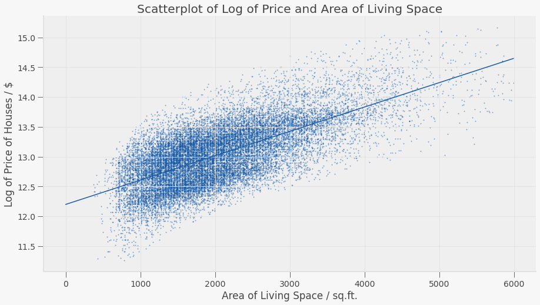

```python
# Add log of price to table
df_kc2["log_price"] = np.log(df_kc2["price"])

# construct the model instance
sqft_lr_model = linear_model.LinearRegression()

# fit the model
sqft_lr_model.fit(df_kc2[["sqft_living"]], df_kc2[["log_price"]])

# print the coefficients
beta_0 = sqft_lr_model.intercept_
beta_1 = sqft_lr_model.coef_[0]

print(f"Fit model: log(price) = {beta_0} + {beta_1} sqft_living")

# Build Graph
fig, ax1 = plt.subplots(figsize=(15, 8))
df_kc2.plot.scatter(x="sqft_living" , y="log_price", alpha=0.35, s=1.5, ax=ax1, title='Scatterplot of Log of Price and Area of Living Space')
x = np.array([0, df_kc2["sqft_living"].max()])
ax1.plot(x, beta_0 + beta_1*x)
ax1.set_xlabel("Area of Living Space / sq.ft.")
ax1.set_ylabel("Log of Price of Houses / $")
plt.show()
```

The scatter plot above shows a linear relationship between Area of living space and Log of price. Using linear regression, the relationship is found to be as follows: **log(price) = 12.1990 + 0.0004 * sqft_living**

```
Fit model: log(price) = [10.66491839] + [0.31093301] grade
```

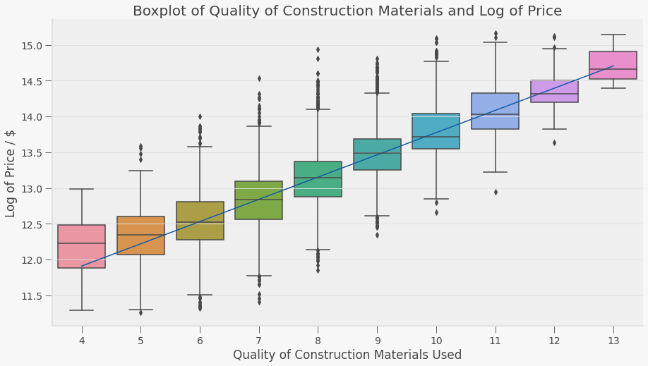

```python
# construct the model instance
grade_lr_model = linear_model.LinearRegression()

# fit the model
grade_lr_model.fit(df_kc2[["grade"]], df_kc2[["log_price"]])

# print the coefficients
beta_2 = grade_lr_model.intercept_
beta_3 = grade_lr_model.coef_[0]

print(f"Fit model: log(price) = {beta_2} + {beta_3} grade")

# Build Graph
fig, ax2 = plt.subplots(figsize=(15, 8))
g = sns.boxplot(x="grade" , y="log_price", ax=ax2, data=df_kc2)
x = np.array([4, df_kc2["grade"].max()])
l = np.array([0, 9])
ax2.plot(l, beta_2 + beta_3*x)
ax2.set(title='Boxplot of Quality of Construction Materials and Log of Price',
       xlabel='Quality of Construction Materials Used', ylabel='Log of Price / $')
plt.show()
```

The boxplot above shows a linear relationship between quality of construction materials used and log of price. Using linear regression, the relationship is found to be as follows: **log(price) = 10.6649 + 0.3109 * grade**. A boxplot is used as grade is a discrete variable. While price and grade have a non-linear relationship, the log of price allows for a simpler linear regression.

```
Fit model: log(price) = [12.25922618] + [0.37202373] bathrooms
```

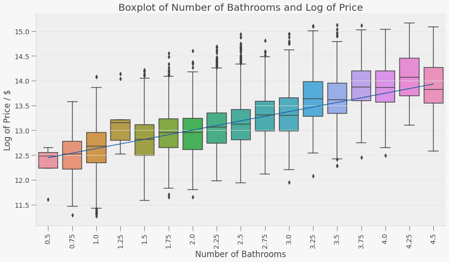

```python
# construct the model instance
bath_lr_model = linear_model.LinearRegression()

# fit the model
bath_lr_model.fit(df_kc2[["bathrooms"]], df_kc2[["log_price"]])

# print the coefficients
beta_4 = bath_lr_model.intercept_
beta_5 = bath_lr_model.coef_[0]

print(f"Fit model: log(price) = {beta_4} + {beta_5} bathrooms")

# Build Graph
fig, ax3 = plt.subplots(figsize=(15, 8))
g = sns.boxplot(x="bathrooms" , y="log_price", ax=ax3, data=df_kc2)
x = np.array([0.5, df_kc2["bathrooms"].max()])
l = np.array([0, 16])
ax3.plot(l, beta_4 + beta_5*x)
plt.xticks(rotation=90)
ax3.set(title='Boxplot of Number of Bathrooms and Log of Price',
       xlabel='Number of Bathrooms', ylabel='Log of Price / $')
plt.show()
```

The boxplot above shows a linear relationship between number of bathrooms and log of price. Using linear regression, the relationship is found to be as follows: **log(price) = 12.2592 + 0.3720 * bathrooms**. A boxplot is used as bathrooms is a discrete variable. While price and bathrooms have a non-linear relationship, the log of price allows for a simpler linear regression.

### 4. Geospatial Representation

Visualizing the geographic distribution gives a more in depth idea of the data. King County is divided into several zipcodes thus these divisions would help represent our data. The first part of this section works towards making a meaningful table of data that is shown below with mean prices, living area, construction material quality and bathrooms for every zipcode. Then it is plotted onto a map that showcases the differences in these mean values for every zipcode. The prices of houses are directly used here instead of log of prices.

```python
county_df = gpd.read_file("http://www2.census.gov/geo/tiger/GENZ2016/shp/cb_2016_us_county_5m.zip")
zipcode = gpd.read_file("https://www2.census.gov/geo/tiger/GENZ2018/shp/cb_2018_us_zcta510_500k.zip")

# Merge the two datasets to filter out the unwanted zipcodes
zipcode['ZCTA5CE10'] = zipcode['ZCTA5CE10'].astype(int)
zips = pd.DataFrame()
zips['zip1'] = df_kc.zipcode.unique()
zipsh = zips.merge(zipcode, left_on='zip1', right_on='ZCTA5CE10', how='inner')
zipsh = gpd.GeoDataFrame(zipsh, geometry='geometry')

# Create a new Data Frame with Mean data of every variable and merge it with geospatial data filtered above
df_kc_mp = df_kc[['zipcode', 'price', 'sqft_living', 'grade', 'bathrooms']].copy()
df_kc_mp2 = df_kc_mp.groupby(['zipcode']).mean()
df_final = zipsh.merge(df_kc_mp2, left_on="ZCTA5CE10", right_on="zipcode", how="inner")
df_final = df_final[['zip1', 'price', 'sqft_living', 'grade', 'bathrooms', 'geometry']].copy().rename(columns={"zip1": "zipcode"})
df_final.head()
```

|  | zipcode | price | sqft_living | grade | bathrooms | geometry |
| --- | --- | --- | --- | --- | --- | --- |
| 0 | 98178 | 310612.755725 | 1729.351145 | 6.816794 | 1.731870 | POLYGON ((-122.28369 47.50997, -122.27855 47.5... |
| 1 | 98125 | 469455.770732 | 1745.507317 | 7.175610 | 1.818902 | POLYGON ((-122.32887 47.72862, -122.32888 47.7... |
| 2 | 98028 | 462480.035336 | 2122.724382 | 7.611307 | 2.143110 | POLYGON ((-122.27414 47.74502, -122.26699 47.7... |
| 3 | 98136 | 551688.673004 | 1726.828897 | 7.403042 | 1.865019 | POLYGON ((-122.39869 47.55750, -122.38146 47.5... |
| 4 | 98074 | 685605.775510 | 2645.870748 | 8.709751 | 2.500000 | POLYGON ((-122.09687 47.64987, -122.09061 47.6... |

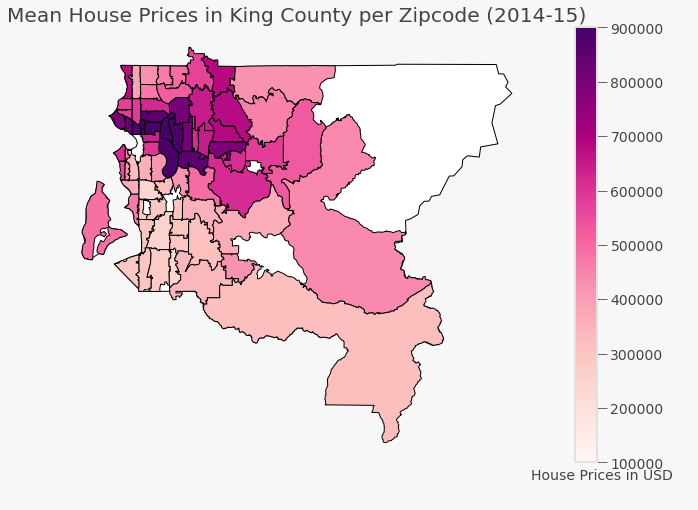

```python
# Plot county
fig, gax = plt.subplots(figsize = (15,8))
county_df.query("COUNTYNS == '01531933'").plot(ax=gax, edgecolor="black", color="white")

#Plot zipcodes and mean prices
df_final.plot(
    ax=gax, edgecolor='black', column='price', legend=True, cmap='RdPu',
    vmin=100000, vmax=900000 #range of your column value for the color legend
)

# add title
gax.set_title('Mean House Prices in King County per Zipcode (2014-15)')
gax.annotate('House Prices in USD',xy=(0.76, 0.06),  xycoords='figure fraction')
plt.axis('off')

plt.show()
```

From the heat map above, it can be seen that mean house prices rise as one goes more towards the north-west areas. The map also shows zipcode with missing house sales data in white. Being able to see the geographical distribution of house sales data is helpful in finding patterns over the county. This allows for targeting specific house groups based on location for instance for economic policies on property taxes.

### 5. Interactive Map

The following map is only for web viewing. Access it by downlaoding this https://drive.google.com/file/d/1Cdc-Uyj6Pez2wJS1lhfXxlMlRF7hLa8j/view?usp=sharing. It is the same map as above except that you can hover over each zipcode to find out the mean prices, living area, construction material quality and number of bathrooms. Different colors scheme has been used in this case to make the best use of color palletes in the bokeh library.

```python
from bokeh.io import output_notebook
from bokeh.plotting import figure, ColumnDataSource
from bokeh.io import output_notebook, show, output_file
from bokeh.plotting import figure
from bokeh.models import GeoJSONDataSource, LinearColorMapper, ColorBar, HoverTool
output_notebook()
import json
#Convert data to geojson for bokeh
fin_geojson=GeoJSONDataSource(geojson=df_final.to_json())
base_geojeson=GeoJSONDataSource(geojson=county_df.query("COUNTYNS == '01531933'").to_json())
```

```python
from bokeh. palettes import Magma10
color_mapper = LinearColorMapper(palette = Magma10, low = 75000, high = 1000000)
color_bar = ColorBar(color_mapper=color_mapper, label_standoff=8,width = 500, height = 20,
                     border_line_color=None,location = (0,0), orientation = 'horizontal')
hover = HoverTool(tooltips = [ ('Zipcode','@zipcode'),('Mean Price in USD', '@price'),
                               ('Mean Sqft Living Area','@sqft_living'),
                               ('Mean Cnstrctn Mtr Qlty','@grade'), ('Mean Bathrooms', '@bathrooms')])
p = figure(title="King County House Sales Data in 2014-15", tools=[hover])
p.patches("xs","ys",source=fin_geojson,
          fill_color = {'field' :'price', 'transform' : color_mapper})
p.add_layout(color_bar, 'below')
show(p)
```

[interactive chart not shown]

## Project 3

### 6. Climate Effect on Seattle House Sales

The research question asks for finding various variables that affect price. With web-scraping techniques, more information apart from the variables present in the existing dataset can be obtained. This data from the web that is not easily downloadable as structured datasets. For instance, https://www.usclimatedata.com/climate/seattle/washington/united-states/uswa0395 provides average monthly data for Seattle climate. The data on Seattle climate includes monthly values such as 'Av. High'(Average High Temperatures), 'Av. Low'(Average Low Temperatures), 'Days precip.'(number of days it rained), 'Hours sun.'(Hours of Sunshine) and 'Av. precip.'(Average amount of rain recieved). Web-scraping thus allows new relationships of climate variables and mean value of sales made every month in Seattle to be explored. Understanding these relationships might give us a deeper insight into how consumers taste and preferences change over climate changes. This data does not need to be scraped frequently as it is not updated on the website that often. According to the website, this climate data is an aggregate of climate normals from years 1981 to 2010.

The data on King County house sales covers areas other than Seattle too. Thus, with the help of web-scraping again, zipcodes only in Seattle will be scraped from https://www.zip-codes.com/city/wa-seattle.asp#zipcodes and merged with the King County dataset so that only information of house sales in Seattle is obtained. This step will come after scraping the data on climate. This data also needs to be scraped only once as zipcodes hardly change.

The climate data in the website is divided into two tables, each with 6 months. Both the tables will be scraped separately and combined later. Additionally, the website has months as columns, however, to be able to merge with the original dataset on King County house sales, climate data must be extracted such that months are in rows.

```python
# Import important packages and call the website in use
import requests
from bs4 import BeautifulSoup

web_url = 'https://www.usclimatedata.com/climate/seattle/washington/united-states/uswa0395'
response = requests.get(web_url)
soup_object = BeautifulSoup(response.content)


# Locate table 1 on website and extract its rows
data_table1 = soup_object.find_all('table', 'table table-hover tablesaw tablesaw-mode-swipe monthly_table')[0]
all_values1 = data_table1.find_all('tr')

# Create a custom dataframe that can be merged with the original dataframe (df_kc)
df1_clmt = pd.DataFrame(columns = ['Month', 'Av. High', 'Av. Low', 'Days Prec.', 'Hrs. Sun.', 'Av. Prec.'])
df1_clmt['Month'] = pd.Series(['Jan', 'Feb', 'Mar', 'Apr', 'May', 'Jun'])

# Add values from online table to the custom dataframe
for i in range(1,6):
    l=[]
    values = all_values1[i].find_all('td')
    for val in values:
        l.append(val.text)
    l = pd.Series(l)
    df1_clmt[df1_clmt.columns[i]] = l


# Locate table 2 on website and extract its rows
data_table2 = soup_object.find_all('table', 'table table-hover tablesaw tablesaw-mode-swipe mb-4 monthly_table')[0]
all_values2 = data_table2.find_all('tr')

# Create a custom dataframe that can be merged with the original dataframe (df_kc)
df2_clmt = pd.DataFrame(columns = ['Month', 'Av. High', 'Av. Low', 'Days Prec.', 'Hrs. Sun.', 'Av. Prec.'])
df2_clmt['Month'] = pd.Series(['Jul', 'Aug', 'Sep', 'Oct', 'Nov', 'Dec'])

# Add values from online table to the custom dataframe
for i in range(1,6):
    l=[]
    values = all_values2[i].find_all('td')
    for val in values:
        l.append(val.text)
    l = pd.Series(l)
    df2_clmt[df2_clmt.columns[i]] = l


# Combine both the tables
df_clmt = pd.concat([df1_clmt, df2_clmt])
# Convert data into numeric values
df_clmt[['Av. High', 'Av. Low', 'Days Prec.', 'Hrs. Sun.']] = df_clmt[['Av. High', 'Av. Low',
                                                                       'Days Prec.', 'Hrs. Sun.']].astype(int)
df_clmt['Av. Prec.'] = df_clmt['Av. Prec.'].astype(float)
df_clmt
```

|  | Month | Av. High | Av. Low | Days Prec. | Hrs. Sun. | Av. Prec. |
| --- | --- | --- | --- | --- | --- | --- |
| 0 | Jan | 45 | 36 | 19 | 74 | 5.20 |
| 1 | Feb | 48 | 37 | 15 | 99 | 3.90 |
| 2 | Mar | 52 | 39 | 16 | 154 | 3.31 |
| 3 | Apr | 58 | 43 | 13 | 201 | 1.97 |
| 4 | May | 64 | 47 | 11 | 247 | 1.57 |
| 5 | Jun | 69 | 52 | 9 | 234 | 1.42 |
| 0 | Jul | 72 | 54 | 5 | 304 | 0.63 |
| 1 | Aug | 73 | 55 | 6 | 248 | 0.75 |
| 2 | Sep | 67 | 52 | 8 | 197 | 1.65 |
| 3 | Oct | 59 | 47 | 14 | 122 | 3.27 |
| 4 | Nov | 51 | 41 | 17 | 77 | 5.00 |
| 5 | Dec | 47 | 38 | 19 | 62 | 5.43 |

The table above shows the final product of the climate data that is web-scraped. The table below shows part of the web-scraped data on Seattle zipcodes.

```python
# Call the website in use
web_url = 'https://www.zip-codes.com/city/wa-seattle.asp#zipcodes'
response = requests.get(web_url)
soup_object = BeautifulSoup(response.content)

# Locate table on website and extract its rows
data_table = soup_object.find_all('table', id='tblZIP')[0]
all_values = data_table.find_all('tr')

df_szc = pd.DataFrame(columns = ['zipcode']) # Create an empty dataframe
ix = 0 # Initialise index to zero

for row in all_values[1:]:
    values = row.find_all('td') # Extract all elements with tag <td>
    # Pick only the text part from the <td> tag
    zipcode = values[0].text

    df_szc.loc[ix] = [zipcode] # Store it in the dataframe as a row
    ix += 1

# Clean data and convert it numeric values
for i in range(60):
    df_szc['zipcode'][i] = df_szc['zipcode'][i][-5:]
df_szc['zipcode'] = df_szc['zipcode'].astype(int)
# Print the first 5 rows of the dataframe
df_szc.head()
```

|  | zipcode |
| --- | --- |
| 0 | 98101 |
| 1 | 98102 |
| 2 | 98103 |
| 3 | 98104 |
| 4 | 98105 |

The web-scraped data can be now merged with King County house sales data to get a meaningful dataset for graphs that will provide some insight on the relationship between climate and mean house sales per month in Seattle.

```python
# Clean the date column values in King County house sales data
pd.options.mode.chained_assignment = None
for i in range(21613):
    df_kc['date'][i] = df_kc['date'][i][:4] + '-' + df_kc['date'][i][4:6] + '-' + df_kc['date'][i][6:8]

# Extract the month values from the dates and put it in a new column as text
pd.to_datetime(df_kc['date'])
df_kc['month'] = pd.DatetimeIndex(df_kc['date']).month
import calendar
df_kc['month'] = df_kc['month'].apply(lambda x: calendar.month_abbr[x])

# Extract only the columns that are required for merging and analysis
df_kc = df_kc[['month', 'price', 'zipcode']].copy()

# Merge this data with the Seattle zipcodes to get only house sales data for Seattle
# and also get the mean of house sales per month
df_kc_mn = df_kc.merge(df_szc, on='zipcode').groupby('month').mean()

df_final = df_clmt.merge(df_kc_mn, left_on='Month', right_on='month')
df_final
```

|  | Month | Av. High | Av. Low | Days Prec. | Hrs. Sun. | Av. Prec. | price | zipcode |
| --- | --- | --- | --- | --- | --- | --- | --- | --- |
| 0 | Jan | 45 | 36 | 19 | 74 | 5.20 | 513691.343358 | 98135.002506 |
| 1 | Feb | 48 | 37 | 15 | 99 | 3.90 | 508383.507042 | 98137.557344 |
| 2 | Mar | 52 | 39 | 16 | 154 | 3.31 | 547247.664928 | 98134.368970 |
| 3 | Apr | 58 | 43 | 13 | 201 | 1.97 | 556922.879915 | 98132.736451 |
| 4 | May | 64 | 47 | 11 | 247 | 1.57 | 539669.403661 | 98131.817919 |
| 5 | Jun | 69 | 52 | 9 | 234 | 1.42 | 538905.340959 | 98134.409586 |
| 6 | Jul | 72 | 54 | 5 | 304 | 0.63 | 546566.131855 | 98132.040840 |
| 7 | Aug | 73 | 55 | 6 | 248 | 0.75 | 517563.488020 | 98135.124842 |
| 8 | Sep | 67 | 52 | 8 | 197 | 1.65 | 530263.452349 | 98133.689933 |
| 9 | Oct | 59 | 47 | 14 | 122 | 3.27 | 534182.988971 | 98132.723039 |
| 10 | Nov | 51 | 41 | 17 | 77 | 5.00 | 520846.929766 | 98133.120401 |
| 11 | Dec | 47 | 38 | 19 | 62 | 5.43 | 534216.957237 | 98133.866776 |

A correlation heatmap at this point would enable us to see how price is related with each of the climate variables.

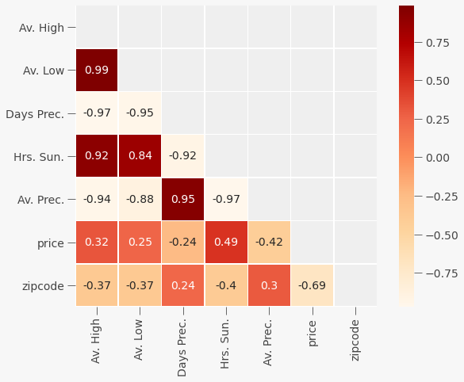

```python
cor = df_final.corr(method = "pearson")
plt.figure(figsize=(10,7))
mask = np.triu(np.ones_like(cor, dtype=bool))
sns.heatmap(cor, mask=mask, annot=True, square=True, linewidth=0.5, cmap='OrRd')
plt.show()
```

#### Graphhical Representation

The first graph shows the positive correlation of hours of sunshine per month and the mean prices of houses per month. This relationship suggests the possibility that demand of houses is higher in sunny months. This may be because people are more eager to set foot outside when the weather is good.

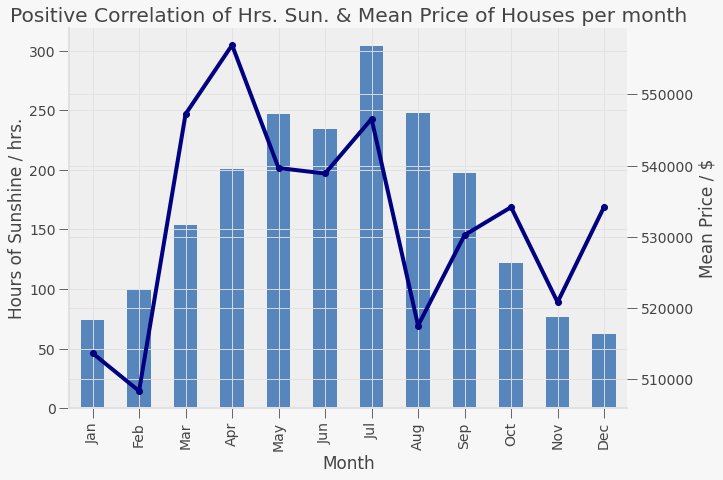

```python
fig = plt.figure(figsize=(10,7))
ax = df_final[('Hrs. Sun.')].plot(kind="bar", alpha=0.7)
plt.xticks(range(len(df_final['Month'])), df_final['Month'])
ax2 = ax.twinx()
ax2.plot(ax.get_xticks(),df_final[('price')],marker='o', c='navy', linewidth=4)
ax.set_xlabel('Month')
ax.set_ylabel('Hours of Sunshine / hrs.')
ax2.set_ylabel('Mean Price / $')
ax.set_title('Positive Correlation of Hrs. Sun. & Mean Price of Houses per month')
ax.spines['top'].set_visible(False)
```

The second graph shows the negative correlation of average precipitation in inches per month and the mean prices of houses per month. This relationship suggests the possibility that demand of houses is higher in less rainy months. This may be because people are more eager to set foot outside when the weather is clear.

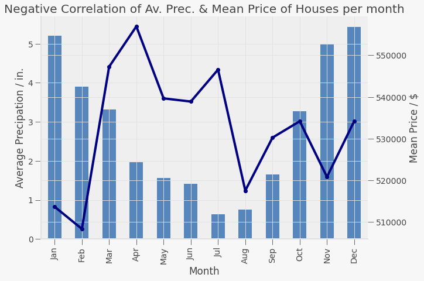

```python
fig = plt.figure(figsize=(10,7))
ax = df_final[('Av. Prec.')].plot(kind="bar", alpha=0.7)
plt.xticks(range(len(df_final['Month'])), df_final['Month'])
ax2 = ax.twinx()
ax2.plot(ax.get_xticks(),df_final[('price')],marker='o', c='navy', linewidth=4)
ax.set_xlabel('Month')
ax.set_ylabel('Average Precipation / in.')
ax2.set_ylabel('Mean Price / $')
ax.set_title('Negative Correlation of Av. Prec. & Mean Price of Houses per month')
ax.spines['top'].set_visible(False)
```

#### Interpretation

While the data suggests that better weather is correlated with higher value of houses sales, it is not a causal relationship. While tastes and preferences of consumers change over time and influences demand, it may also be that it is changing because of factors other than climate. For instance, when the consumers get their annual income or when they need to pay annual taxes might affect when they are willing to spend more. Another factor that can be included is when do the consumers have the most holidays or most amount of time to spend apart from work to search for houses thus increase demand and mean prices of houses that month.

### 7. OLS Regression

Various variables and their relationship on house sales were explored above. To answer the second part of the research question, that is to accurately predict house sales, a formula must be formed based on the variables in the primary focus - sqft_living, grade and bathrooms. Models to predict prices can be made by individually using variables or combining them. Not all three variables may necessarily be required thus an OLS regression analysis would be required to select the best model. The three given variables are specifically chosen as they have the highest correlation with price individually. All of them have a linear relationship with the natural log of price as mentioned in the 'Graphical Representation' section. Four models can be generated and tested for best predicting price:

**Model 1 :** log(price) = constant + (beta1 * sqft_living) + Є

**Model 2 :** log(price) = constant + (beta1 * grade) + Є

**Model 3 :** log(price) = constant + (beta1 *sqft_living) + (beta2* grade) + Є

**Model 4 :** log(price) = constant + (beta1 *sqft_living) + (beta2* grade) + (beta3 * bathrooms) + Є

These models were constructed based on their relative relevance over price and to assess their relationship with each other. If the variables are similar to each other, they would not be helpful in reducing the error term, Є as they predict price based on similar characteristics. For instance, the number of bathrooms may be positively correlated with the area of living space thus if both the variables are to be used in the same model as model 4, they may not reduce Є significantly compared to only using sqft_living as in Model 3. On the other hand, grade and sqft_living may be relatively more independant from each other, which would suggest that they are better able to predict price.

```python
# Add constant term to dataset
df_kc2['const'] = 1

# Create lists of variables to be used in each regression
X1 = ['const', 'sqft_living']
X2 = ['const', 'grade']
X3 = ['const', 'sqft_living', 'grade']
X4 = ['const', 'sqft_living', 'grade', 'bathrooms']

# Estimate an OLS regression for each set of variables
reg1 = sm.OLS(df_kc2['log_price'], df_kc2[X1], missing='drop').fit()
reg2 = sm.OLS(df_kc2['log_price'], df_kc2[X2], missing='drop').fit()
reg3 = sm.OLS(df_kc2['log_price'], df_kc2[X3], missing='drop').fit()
reg4 = sm.OLS(df_kc2['log_price'], df_kc2[X4], missing='drop').fit()
```

```python
from statsmodels.iolib.summary2 import summary_col
info_dict={'R-squared Adjusted' : lambda x: f"{x.rsquared_adj:.2f}",
           'No. observations' : lambda x: f"{int(x.nobs):d}",
           'AIC' : lambda x: f"{x.aic:.2f}",
           'BIC' : lambda x: f"{x.bic:.2f}"}
```

```python
results_table = summary_col(results=[reg1,reg2,reg3, reg4],
                            float_format='%0.4f',
                            stars = True,
                            model_names=['Model 1',
                                         'Model 2',
                                         'Model 3',
                                         'Model 4'],
                            info_dict=info_dict,
                            regressor_order=['const',
                                             'sqft_living',
                                             'grade',
                                             'bathrooms'])
# x.fvalue, x.f_pvalue
results_table.add_title('Table - OLS Regressions')

print(results_table)
```

```
                   Table - OLS Regressions
==============================================================
                    Model 1    Model 2    Model 3    Model 4
--------------------------------------------------------------
const              12.1991*** 10.6649*** 11.1751*** 11.1752***
                   (0.0067)   (0.0171)   (0.0188)   (0.0188)
sqft_living        0.0004***             0.0002***  0.0002***
                   (0.0000)              (0.0000)   (0.0000)
grade                         0.3109***  0.1837***  0.1866***
                              (0.0022)   (0.0032)   (0.0033)
bathrooms                                           -0.0203***
                                                    (0.0049)
R-squared          0.4665     0.4779     0.5384     0.5387
                   0.4666     0.4779     0.5384     0.5388
R-squared Adjusted 0.47       0.48       0.54       0.54
No. observations   21483      21483      21483      21483
AIC                19010.07   18546.87   15903.99   15889.06
BIC                19026.02   18562.82   15927.91   15920.96
==============================================================
Standard errors in parentheses.
* p<.1, ** p<.05, ***p<.01
```

From the models above, it is statistically usefull to choose Model 3. It is best able to reduce Є while using only 2 variables. Statistically, it is in the best interest to have a high R-squared, p-value lower than 0.05 and low AIC and BIC. Model 3 achieves that best compared to Model 1 and 2. Model 4 is better able to achieve these objectives, however, it is a very slight change compared to Model 3 while a whole new variable is added. Therefore, for simplicity, Model 3 is chosen to answer the research question on how to predict King County House Sales:

**Model 3 :** log(price) = 11.1751 + (0.0002 *sqft_living) + (0.1837* grade) + Є

### 8. Conclusion

Upon going over the various variables that affect house sales prices in King County, area of living space and quality of construction materials used were found to be the most accurate at predicting prices with the following equation:

**Model 3 :** log(price) = 11.1751 + (0.0002 *sqft_living) + (0.1837* grade) + Є

The paper also looked at geospatial and climate effects on house prices. Mean prices increased towards the north west of the county and clearer months seemed to correlate with higher prices in Seattle.